# Lecospec

## Laboratory of Ecological Spectroscopy (lecospec)

The purpose of lecospec code, called lecospectR, is to take ground or image based reflectance spectra, build a classifier or regression, apply that model to an imaging spectrometer data cube (aka hyperspectral image).

Requirements: R v4.2.3 is now the only stable environment ro run lecospectR. Rtools 4.2 is also needed to be able to use devtools.

1. First, install dependencies

   source(“./Scripts/Utilites/install_dependencies.R”) NOTE: This may take awhile and one package, hsdar, must be installed from a stable, read-only copy on CRAN Github.
2. Then load the package of lecospectR

   source(“./Functions/lecospectR.R”)

The functions in lecospectR are divided into sections, Some functions are found in lecospectR.R but all of which are loaded by sourcing /Functions/lecospectR.R.

```
/Functions/dataframe_operations.R
/Functions/model_support.R
/Functions/pfts.R
/Functions/pipeline.R
/Functions/raster_operations.R
/Functions/site_specific_processing.R
/Functions/spectral_operations.R
/Functions/training_utilities.R
/Functions/type_conversion.R
/Functions/utilities.R
/Functions/validation.R
/Functions/visualization.R
```

## Build a spectral library from ground data

1. Our workflow assumes a list of species with associated levels of taxonomic information (eg. functional group membership) /Data/SpeciesTable_202230417.csv. This table is used for several steps, including aggregating validation to the same taxonomic level as training data. This table will be specific to whatever classification targets one is working with. To use lecospec, associated files are needed that are generated based on this species table are created by running the following script:

The outputs of this script are written to assets/.

2. Build a spectral library from a range of field scans collected with Tungsten halogen illumination using a leaf clip or contact probe. These scripts delete bad scans and standardize the associated information into a single metadata format.

   /Scripts/TrainingDataCreation/Ground/2_DataMunging.R  
   /Scripts/TrainingDataCreation/Ground/2B_DataMunging_missing_spectra.R  
   /Scripts/TrainingDataCreation/Ground/3_Create_SpecLibPSR.R

The output of running these scripts is spectral library reflectance and the metadata.

```
/Output/C_001_SC3_Cleaned_SpectralLib.csv
```

## Build a spectral library from images

1. Collect spectra from pixels in images from UAV in quadrats and patches of plant functional types visible in ground reference or higher resolution RGB imagery. Reflectance spectra are extracted from hand digitized patches of plant functional types provided as a shapefile to the first script (101_Crop_Training_PFT_vector). The same operation is performed in the second script (101_Crop_Training_Quads) for hand digitzed quadrats of validation ground cover data. Script 102_Parse_training_PFT_vector_spectra adds metadata to each pixel by plant patch.

   /Scripts/TrainingDataCreation/Image/101_Crop_Training_PFT_vector.R /Scripts/TrainingDataCreation/Image/101_Crop_Training_Quads.R /Scripts/TrainingDataCreation/Image/102_Parse_training_PFT_vector_spectra.R /Scripts/TrainingDataCreation/Image/103_Clean_training_PFT_vector_spectra.R
2. After running these scripts, the output is relectance for each pixel from the patches of plants digitized from images.

   /Data/Ground_Validation/PFT_Image_spectra/PFT_Image_SpectralLib_Clean.csv

## Compare ground and image spectra

1. Visually compare the reflectance profiles of plant functional types between ground spectra and image spectra. We generated the figure below by calculating median reflectance and other quantiles by band, source and plant functional type. We then plotted the quantiles (red or blue = median, 75% black & 95% grey). Sample sizes (pixels for image data, scans for ground data), number of unique taxa and number of patches (for image data only) are also calculated and written to the header of each panel. These steps are done in the following script.

   /Scripts/ExploratoryDataAnalysis/106_Compare_ground_image_spectra.R

Other routines are also in this script, including principle components analysis and associated visualizations, which would need to be modified for a new application.

[figure not shown]

## Study Area and Data locations

The centers of all UAV flights and points where ground scans were collected are shown in the map. Collecting these locations from the metadata and image centers for data collected as the Arctic boreal plant mapping use case for lecospectR using the /Scripts/ExploratoryDataAnalysis/7_Visualizations_Ground_and_UAS_Spectra_locations.R which produces the two .kml files plotted in the map below. The image below it shows one site (Bison Gulch near Denali National Park) with ground validation quadrat locations (squares) along 100 m long transect with a white calibration tarp on one end.

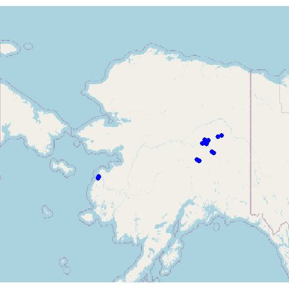

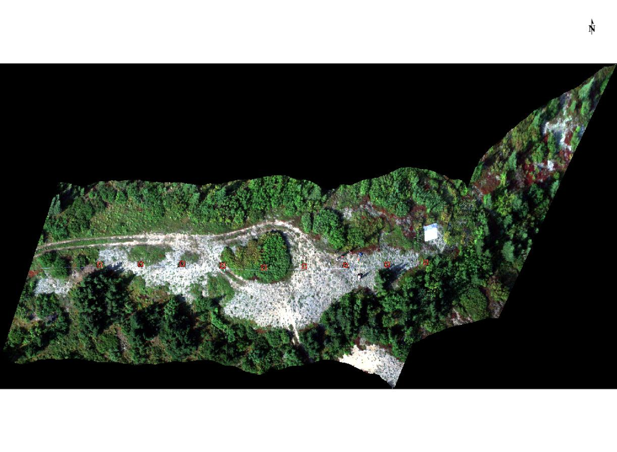

## Building patch or site balanced test/train splits for the data across different bandpasses and sample sizes

Since each plant functional type has different numbers of species, scans and sites/patches, balancing the data used in building classification models requires selecting a train and testing split that accounts for the differences. Also, the width of each band may change the ability to separate the different plant functional types. The script below builds training and testing partitions with different maximum samples sizes (125, 300, 500, 750, 1000 and 2000 pixels) per plant functional type and across different bandpasses (5,10,25 and 50nm). Some plant functional types have fewere than 300 pixels so as the max sample size increases, so does the bias towards plant functional types with more pixels. The maximum sample size only applies to the training dataset. The testing dataset is set at 20 pixels per plant functional type.

```
./build_balanced_ground_data
./build_balanced_training_data
```

The outputs of these scripts are written to ./Data/v2/ as .csv files, once for each combination of test/train, wavelength and max sample size per plant functional type.

## Model training and validation

1. Set all the input, output and needed associated files for building models and predicting images in the following file.

   /Scripts/validation_defs.R

Variable set in this script include: test_paths, which are rasters only with the pixels by quadrat by site shape_paths, which are the vectors of the edges of each quadrat by site validation_paths, which are tabular data of ocular estimated cover of plants by a human based on ground photos lists of names of quadrat vectors by site (eg. bison_gulch_names <- c(“Bisongulch0”,“Bisongulch60”,“Bisongulch70”,“Bisongulch10”,“Bisongulch80”,“Bisongulch20”,“Bisongulch50”,“Bisongulch30”,“Bisongulch40”))

2. Several types of models are built in lecospec, including two bagged regression trees (ranger and adaboost) and partial least squares regression (PLS). To build these models, use the following scripts at the root of the directory.

   ./gs3_adaboost.R ./gs3_rf.R ./gs3_pls.R

Other models have been tested but not fully explored include support vector machines (SVM), CART, boosted regression trees (Xgboost).

```
./gs3_svm.R
./gs3_cart.R
```

Each model script has a similar set up, with the parameters for the model to be searched described at the beginning of the script.

model hyperparameters num_components <- 2^seq(0, 10) alpha <- seq(0, 1, 0.1)

4. Each model output is written to a folder with the same name as the model, such as the example below. Each model is given a unique identifier when it is built.

   ./mle/experiments/gs/“MODEL UUID HERE”

Model outputs include predictions for each ground validation sample (quadrat) as a raster as well as histogram comparing the observed proportion of pixels in each quadrat per plant functional type against the predicted proportion from lecospec. These are all aggregated into a single figure called aggergate.html, which shows the observes vs predicted cover proportion by quadrat, plant funnctional type and site. All models for a particular algorithm type (eg. pls) have summary statistics written to a log file at the root with the same name as the model script (eg. ./gs3_adaboost.R makes a log file at ./gs3_adaboost.csv). The log file makes it easy to sort models by accuracy (percent pixels correctly identified) and fit (sum of squared residuals of observed vs predicted values)

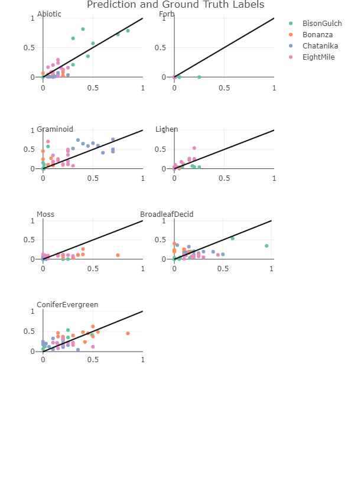

5. After exploring model outputs based on different input data, Pick and model and explore results with lecospectR::validate_model.R , whicih calls the input data, models and settings from validate_def.R

   ./gs/models/gs/“MODEL UUID HERE”
6. Generate predidctions for plant functional type occurence for whole datacubes by running the parallelized estimate_landcover function from lecospectR. Set the number of tiles carefully based on RAM and image size. To run the function lecospectR::estimate_landcover, change the settings at the following file.

   ./config.json

The setting included in this config control which model is used, tiling settings, parallelization, etc..

```
automatic_tiling: false
max_size: 200
x_tiles: 2 # Set to make about 10% of RAM size on machine
y_tiles: 2
tile_path: "./tiles/" #Intermediate products go here, like /temp. Will need to be cleaned out every so often
model_path: "./mle/"INSERT MOD NAME".rda" #Models built in /modelbuilding.ipynb can be pasted here
clusterCores: (NUM CORES ON MACHINE - 1) #Speeds up the processing on larger images to have more cores but tradeoff between handling tiles and creating tiles exists
parallelize_by_tiles: false
key_path: "./fg2key.json"
external_bands: "./bands.csv" #Bands used to rename spectral objects consistently along the way
output_format: "grd"
aggregation: 1 #Depends on levels within data and only relevant for taxonomic-like structured response categories
```

7. Once the settings match what is needed, the following script tests the model smaller on a small image. If that succeeds, the script shows using the model on large images, converting them to different image formats for plotting and then saving a low resolution image of the output map of plant functional types (with a legend)

   ./Scripts/ExploratoryDataAnalysis/run_prn.R

Example predicted plant functional type map from one site (Bison Gulch near Denali National Park)

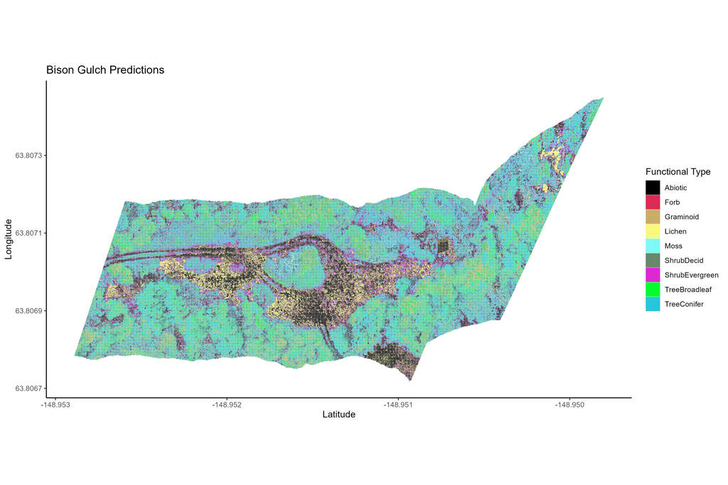